# LMS 방법의 개요

시립대학교 통계학과 이용희

2018년 9월 11일

# Centile Chart

일반적으로 여러 가지 신체 지수(키, 몸무게, BMI 등)들을 연구할 때 시간에 따른 신체의 변화와 분포의 극단적인 부분(아주 작거나 큰 부분)에 대한 정보가 필요하다.

이러한 신체지수 분포에서 백분위수가 시간에 따라서 변하는 추세를 평활한 곡선으로 나타낸 것을 **centile chart**라고 하며 성장곡선(growth curve)를 백분위수에 따라 그린 그림이다.

LMS 방법은 표본 자료를 이용하여 모집단의 백분위수를 추정하는 방법 중의 하나이다. 특히 관심있는 변수의 극단적인 백분위수의 값을 공변량(예를 들어 나이, age)의 변화에 대하여 평활하게(smoothly) 변한다고 가정하고 추정하는 방법이다.

> The general form of a centile chart is a series of smoothed centile curves, showing how selected centiles for the measurement change when plotted against some independent variable. The independent variable is commonly age or time, and to simplify somewhat it is referred to here as time (Cole, 1988)

[figure not shown]

Centile curve의 예제 1

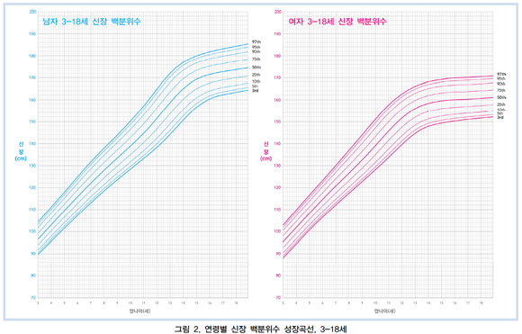

Centile curve의 예제 2

# LMS 방법

### LMS 방법의 개요

LMS 는 자료의 분포를 다음과 같은 세 종류의 기술통계량으로 표현하기 때문에 각 통계량의 첫 문자(Lamnbda, Mean, Sigma)를 따서 이름이 생긴 방법이다.

- L (=$\lambda$): power parameter in Box-Cox transformation
  $$X = \frac{(Y/\mu)^\lambda -1}{\lambda} \sim \text{ Normal distribution}$$
- M (=$\mu$) : 분포의 평균, mean of distrinution, $\mu=E(Y)$
- S (=$\sigma$) 분포의 변동계수, coefficient of variation, $\sigma= \sqrt{Var(Y)}/\mu=SD(y)/E(Y)$

LMS 방법은 자료에 특정한 변환을 하면 정규분포를 따른다고 가정하고 변환된 자료의 평균과 변동계수가 공변량의 변화에 따라 평활하게 변화한다고 가정하고 백분위수를 추정하는 것이다.

> The three parameters are constrained to change smoothly as the covariate changes, and can, like the centiles, be plotted against the covariate.

### BOX-COX 변환

관심있는 변수를 $Y$라고 하고 이 변수는 BOX-COX 변환을 하면 정규분포를 따른다고 가정한다.
$$X =
\begin{cases}
\frac{(Y/\mu)^\lambda -1}{\lambda} & \text{ if } \lambda \ne 0 \\
\log(Y/\mu) & \text{ if } \lambda = 0
\end{cases}$$
여기서 $\mu$는 변수 $Y$의 중앙값(median)이다.

### 표준화 변수

이제 변환된 변수 $X$의 표분편차(이는 원래 변수 $Y$의 변동계수와 같다)를 $\sigma$라고 하고 다음과 같이 표준화 변수 $z$를 정의하자.

$$\begin{equation} z =
\begin{cases}
\frac{X}{\sigma} = \frac{(Y/\mu)^\lambda -1}{\lambda \sigma } & \text{ if } \lambda \ne 0 \quad Eq (1)\\
\frac{\log(Y/\mu)}{\sigma} & \text{ if } \lambda = 0 \quad Eq (2)
\end{cases}
\end{equation}$$

### 그룹별 적합과 평활

위에서 수행한 작업, 즉 Box-Cox 변환과 표준하 변수를 만드는 작업을 각 그룹별(공변량 $t$ 에 대하여)로 실시한다. 예를 들어 나이가 공변량이라면 연령별로 전체 표본을 나눈다(1년 단위로 $t_1$=1세, $t_2$=2세, …. $t_k$=k세) 이렇게 $i$ 그룹에 대해서 구한 ($\lambda_i$, $\mu_i$, $\sigma_i$)를 이용하여 다음과 같이 공변량 $t$에 대한 평활한 함수(smoothing function)를 추정한다.

$$L(t_i) = \lambda(t_i)=\lambda_i, \quad M(t_i) = \mu(t_i) =\mu_i ,\quad S(t_i) = \sigma(t_i) =\sigma_i, \
\quad i=1,2,\dots,k$$

평활함수 추정은 스플라인 함수 추정 등 통계학에서 자주 사용되는 평활함수추정법을 사용한다.

### 백분위수 추정

이제 위에서 추정한 함수 $ L(t),M(t),S(t)$를 사용하여 위에서 나타난 식 (1)과 (2)에 대입하면 주어진 공변량의 값 $t$에 대하여 다음과 같은 관계를 구한다.

$$\begin{equation} z =
\begin{cases}
\frac{[Y/M(t)]^{L(t)} -1}{L(t) S(t) } & \text{ if } L(t) \ne 0 \quad Eq (3)\\
\frac{\log(Y/M(t))}{S(t)} & \text{ if } L(t) = 0 \quad Eq (4)
\end{cases}
\end{equation}$$

이제 주어진 공변량의 값 $t$에 대하여 식 (3)과 (4)에 $z$를 정규분포 백분위수 $z_\alpha$로 바꾸고 $y$에 대하여 풀면 $y$의 $100\alpha$ % 백분위수 $y_\alpha(t)$를 구할 수 있다. 즉

$$\begin{equation} y_\alpha(t) =
\begin{cases}
M(t) ( 1+ L(t) S(t) z_\alpha) ^{1/L(t)} & \text{ if } L(t) \ne 0 \\
M(t) \exp(S(t)z_\alpha) & \text{ if } L(t) = 0
\end{cases}
\end{equation}$$

# `R` 패키지와 예제: 나이에 따른 BMI centile curve

LMS 방법을 구현할 수 있는 `R` 패키지는 `quantregGrowth`, `gamlss` 등이 있다.

`R` 패키지 `gamlss`를 이용한 간단한 예제 **The Dutch boys BMI data**에서 나이에 따른 BMI centile curve 를 추정하는 방법을 살펴보겠다

- Data from the Fourth Dutch Growth Study,
- A cross-sectional study that measures growth and development of the Dutch population between the ages 0 and 21 years.
- The study measured, among other variables, height, weight, head circumference and age for 7482 males and 7018 females.
- Flexible Regression and Smoothing The GAMLSS packages in R, 2015, pp 309-346

```r
#install.packages("gamlss")
library(gamlss)
```

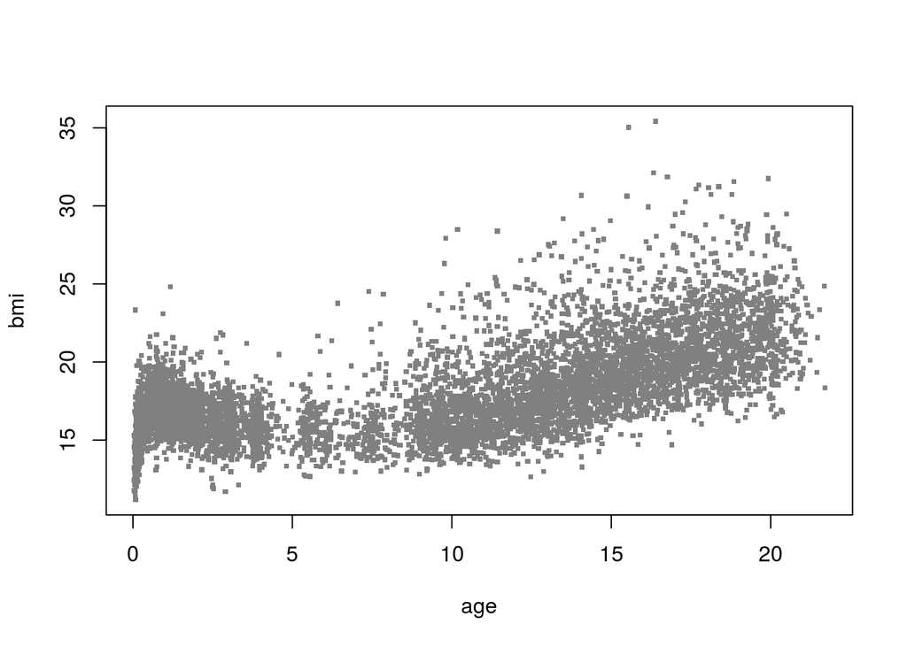

```r
data(dbbmi)
plot(bmi~age, data=dbbmi, pch = 15, cex = 0.5, col = gray(0.5))
```

이제 `lms`함수를 이용하여 변환에 대한 정보를 얻어보자. 잔체 자료를 다 사용하지 않고 1000개만 임의추출하여 사용한다.

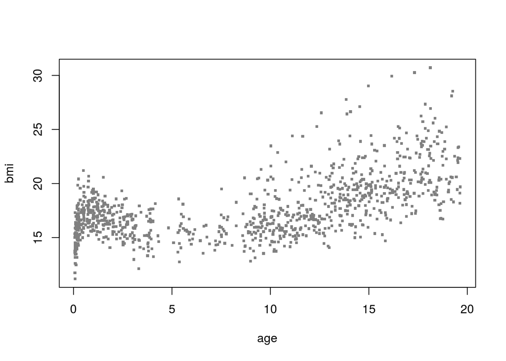

```r
set.seed(2803)
IND<-sample.int(7040, 1000, replace=FALSE)
dbbmi1 <- dbbmi[IND,]
plot(bmi~age, data=dbbmi1, pch = 15, cex = 0.5, col = gray(0.5))
```

```r
m0 <- lms(bmi,age, data=dbbmi1, trans.x=T, k=2)
```

```
## *** Checking for transformation for x ***
## *** power parameters  0.3294879 ***
## *** Initial  fit***
## GAMLSS-RS iteration 1: Global Deviance = 4260.768
## GAMLSS-RS iteration 2: Global Deviance = 4260.768
## *** Fitting BCCGo ***
## GAMLSS-RS iteration 1: Global Deviance = 3955.061
## GAMLSS-RS iteration 2: Global Deviance = 3940.976
## GAMLSS-RS iteration 3: Global Deviance = 3939.737
## GAMLSS-RS iteration 4: Global Deviance = 3939.634
## GAMLSS-RS iteration 5: Global Deviance = 3939.617
## GAMLSS-RS iteration 6: Global Deviance = 3939.613
## GAMLSS-RS iteration 7: Global Deviance = 3939.611
## GAMLSS-RS iteration 8: Global Deviance = 3939.61
## *** Fitting BCPEo ***
## GAMLSS-RS iteration 1: Global Deviance = 3967.61
## GAMLSS-RS iteration 2: Global Deviance = 3941.236
## GAMLSS-RS iteration 3: Global Deviance = 3938.958
## GAMLSS-RS iteration 4: Global Deviance = 3938.715
## GAMLSS-RS iteration 5: Global Deviance = 3938.679
## GAMLSS-RS iteration 6: Global Deviance = 3938.665
## GAMLSS-RS iteration 7: Global Deviance = 3938.66
## GAMLSS-RS iteration 8: Global Deviance = 3938.659
## GAMLSS-RS iteration 9: Global Deviance = 3938.658
## *** Fitting BCTo ***
## GAMLSS-RS iteration 1: Global Deviance = 3946.803
## GAMLSS-RS iteration 2: Global Deviance = 3941.374
## GAMLSS-RS iteration 3: Global Deviance = 3940.269
## GAMLSS-RS iteration 4: Global Deviance = 3939.766
```

```
## GAMLSS-RS iteration 5: Global Deviance = 3939.551
```

```
## GAMLSS-RS iteration 6: Global Deviance = 3939.553
```

```
## GAMLSS-RS iteration 7: Global Deviance = 3939.585
## GAMLSS-RS iteration 8: Global Deviance = 3939.603
## GAMLSS-RS iteration 9: Global Deviance = 3939.608
## GAMLSS-RS iteration 10: Global Deviance = 3939.609
## GAMLSS-RS iteration 11: Global Deviance = 3939.61
```

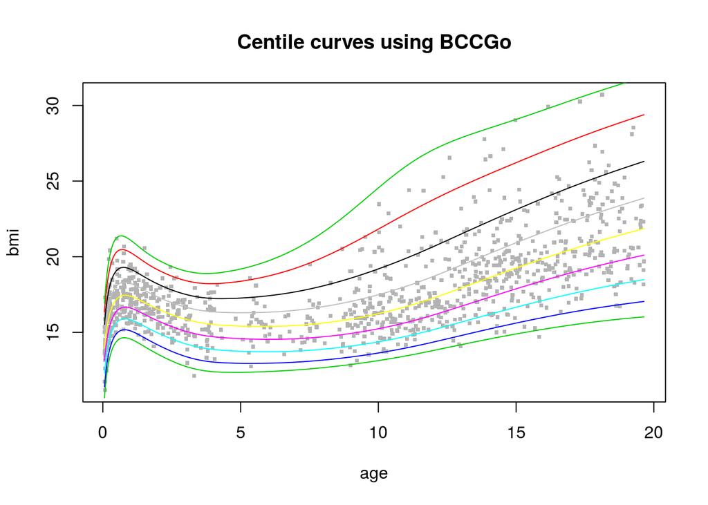

```
## % of cases below  0.4252834 centile is  0.4
## % of cases below  1.93571 centile is  2.3
## % of cases below  8.774859 centile is  9.2
## % of cases below  25.55662 centile is  25.3
## % of cases below  49.94412 centile is  50
## % of cases below  74.2983 centile is  74.7
## % of cases below  90.8258 centile is  90.8
## % of cases below  98.00292 centile is  97.7
## % of cases below  99.46541 centile is  99.6
```

# 참고문헌

- Cole, T. J. ‘Fitting smoothed centile curves to reference data (with Discussion)’, Journal of the Royal Statistical Society, Series A, 151, 385418 (1988).
- Cole, T. J. ‘The LMS method for constructing normalized growth standards’, European Journal of Clinical Nutrition, 44, 4 5 4 0 (1990).
- Cole, T. J. and Green, P. J. (1992), Smoothing reference centile curves: The lms method and penalized likelihood. Statist. Med., 11: 1305-1319.
- Flexible Regression and Smoothing The GAMLSS packages in R, 2015